# Lesson 03 - Artificial Neural Networks

### The following topics are discussed in this notebook:

- The architecture of an artificial neural network.
- Building neural networks in keras.

### Additional Resources

- **Deep Learning with Python**, Section 3.4, Pages 68 - 77

```python
import numpy as np
import matplotlib.pyplot as plt
```

As we saw in the previous lesson, logistic regression models (which consist of a single artifial neuron) always result in a linear decision boundary. While that might be appropriate for some problems, there are many problems for which a linear decision boundary will be insufficient. For those types of problems, we will need a more complex model. This can be achieved by stacking individual neurons together into an **artificial neural network**.

An ANN consists of many layers of neurons, which are processed in a specific order. There are three types of layers in an ANN: The input layer, one or more hidden layers, and an output layer.

- The first layer, called the **input layer**, consist of the features being fed into the model. It contains one node for each feature being used, plus a single bias node.
- The output of each node in the input layer is sent to each (non-bias) node in the first **hidden layer**. Every connection between any two pair of nodes in these two layers will have its own weight. The nodes in the first hidden layer process the inputs it recieves from the input layer, and send their outputs downstream to any subsequent hidden layers.
- The last hidden layer will send its output to an **output** layer. This output layer could contain one or more neurons, depending on the type of task that the network is being used for.

We can build a neural network with as many hidden layers as we wish, and each hidden layer can have as many nodes as we would like. As a general rule, the more neurons that there are in a model, the more flexible that model is.

[figure not shown]

# Example 1

The first neural network that we will build will be to tackle the following classification problem.

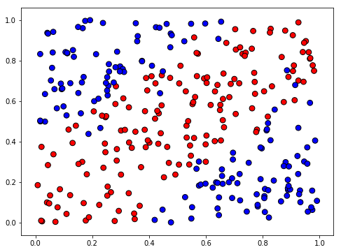

```python
np.random.seed(887)
X = np.random.uniform(0,1,[300,2])
pB = 40*np.abs(X[:,0] - X[:,1])**4
pR = np.random.uniform(0,1,300)
col = np.where(pB < pR, 'r', 'b')
y = np.where(pB < pR, 0, 1)

plt.figure(figsize=(8,6))
plt.scatter(X[:,0], X[:,1], c=col, edgecolor='k', s=60)
plt.show()
```

## Network Architecture

We will use keras to build a neural network with one hidden layer, containing four (non-bias) nodes.

[figure not shown]

## Import Keras Modules

We will be using the Keras package to construct neural networks in this course. Keras provides a high-level API for building neural networks. It is built on top of TensorFlow, which is a library created by Google to efficiently perform matrix calculations.

We will now import some Keras modules that we will need to build our network.

```python
from keras.models import Sequential
from keras.layers import Dense
from keras.optimizers import Adam
from tensorflow import set_random_seed
```

## Construct the Network

We will now specify our network architecture by creating a class of type `Sequential` to represent our model. We will then add the necessary layers to our model.

```python
np.random.seed(1)
set_random_seed(1)

model = Sequential()
model.add(Dense(4, input_shape=(2,), activation='sigmoid'))
model.add(Dense(1, activation='sigmoid'))
```

We can use the `summary` method to view a description of our model.

```python
model.summary()
```

```
_________________________________________________________________
Layer (type)                 Output Shape              Param #
=================================================================
dense_1 (Dense)              (None, 4)                 12
_________________________________________________________________
dense_2 (Dense)              (None, 1)                 5
=================================================================
Total params: 17
Trainable params: 17
Non-trainable params: 0
_________________________________________________________________
```

## Compile the Model

Before we train the model, we need to specify what loss function to minimize, as well as what optimization method we will use to (hopefully) achieve that minimization. We can do this with the `compile` method of the `Sequential` class. We can also use compile to specify useful metrics other than the loss to be reported during training.

```python
opt = Adam(lr=0.1)
model.compile(loss='binary_crossentropy', optimizer=opt, metrics=['accuracy'])
```

## Training the Model

We will now train the model using the `fit` method. We specify values for the following parameters in the `fit` method below:

- **`batch_size`** refers to the number of samples to calculate the loss on at one time. The weights will be updated after each batch. We will include the entire training set as our batch, but there can be advantages to using smaller batches. A single training loop will consider every sample in the data set, even if we are using multiple batches.
- **`epochs`** is the number of training loops to perform.
- **`verbose`** determines the amount of information displayed while training. If `verbose=0`, then no ouput is displayed. If `verbose=2`, then loss and any requested metrics are shown after each epoch. Setting `verbose=1` is similar to `verbose=2`, except that you will see a progress bar as well as execution time for each epoch.

```python
h = model.fit(X, y, batch_size=300, epochs=200, verbose=2)
```

```
 - 1s - loss: 0.6969 - acc: 0.3967
 - 0s - loss: 0.6953 - acc: 0.5333
 - 0s - loss: 0.6960 - acc: 0.5200
 - 0s - loss: 0.6917 - acc: 0.6933
 - 0s - loss: 0.6918 - acc: 0.4333
 - 0s - loss: 0.6939 - acc: 0.2833
 - 0s - loss: 0.6929 - acc: 0.3333
 - 0s - loss: 0.6910 - acc: 0.5333
 - 0s - loss: 0.6908 - acc: 0.6967
 - 0s - loss: 0.6918 - acc: 0.6500
 - 0s - loss: 0.6919 - acc: 0.6500
 - 0s - loss: 0.6908 - acc: 0.6933
 - 0s - loss: 0.6899 - acc: 0.6533
 - 0s - loss: 0.6900 - acc: 0.5267
 - 0s - loss: 0.6904 - acc: 0.4267
 - 0s - loss: 0.6900 - acc: 0.4400
 - 0s - loss: 0.6891 - acc: 0.5333
 - 0s - loss: 0.6885 - acc: 0.6367
 - 0s - loss: 0.6883 - acc: 0.6933
 - 0s - loss: 0.6882 - acc: 0.7000
 - 0s - loss: 0.6876 - acc: 0.7133
 - 0s - loss: 0.6867 - acc: 0.6833
 - 0s - loss: 0.6859 - acc: 0.6300
 - 0s - loss: 0.6854 - acc: 0.5867
 - 0s - loss: 0.6848 - acc: 0.5433
 - 0s - loss: 0.6838 - acc: 0.5800
 - 0s - loss: 0.6825 - acc: 0.6200
 - 0s - loss: 0.6814 - acc: 0.6667
 - 0s - loss: 0.6802 - acc: 0.7000
 - 0s - loss: 0.6789 - acc: 0.7033
 - 0s - loss: 0.6772 - acc: 0.6867
 - 0s - loss: 0.6753 - acc: 0.6700
 - 0s - loss: 0.6734 - acc: 0.6400
 - 0s - loss: 0.6714 - acc: 0.6200
 - 0s - loss: 0.6690 - acc: 0.6367
 - 0s - loss: 0.6664 - acc: 0.6567
 - 0s - loss: 0.6636 - acc: 0.6800
 - 0s - loss: 0.6606 - acc: 0.6867
 - 0s - loss: 0.6574 - acc: 0.6900
 - 0s - loss: 0.6539 - acc: 0.6900
```

[output cut: 145 more lines]

```
 - 0s - loss: 0.1431 - acc: 0.9533
 - 0s - loss: 0.1430 - acc: 0.9533
 - 0s - loss: 0.1429 - acc: 0.9533
 - 0s - loss: 0.1428 - acc: 0.9533
 - 0s - loss: 0.1428 - acc: 0.9533
 - 0s - loss: 0.1427 - acc: 0.9533
 - 0s - loss: 0.1426 - acc: 0.9533
 - 0s - loss: 0.1425 - acc: 0.9533
 - 0s - loss: 0.1424 - acc: 0.9533
 - 0s - loss: 0.1424 - acc: 0.9533
 - 0s - loss: 0.1423 - acc: 0.9533
 - 0s - loss: 0.1422 - acc: 0.9533
 - 0s - loss: 0.1421 - acc: 0.9533
 - 0s - loss: 0.1421 - acc: 0.9533
 - 0s - loss: 0.1420 - acc: 0.9533
```

## Analyzing Training Process

The output of the `fit` method contains a `history` attribute that we can use to visualize the changes in loss and accuracy during the training process.

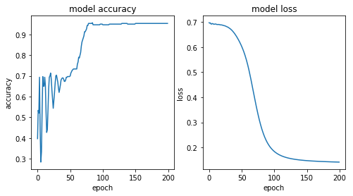

```python
plt.rcParams["figure.figsize"] = [8,4]
plt.subplot(1,2,1)
plt.plot(h.history['acc'])
plt.title('model accuracy')
plt.ylabel('accuracy')
plt.xlabel('epoch')

plt.subplot(1,2,2)
plt.plot(h.history['loss'])
plt.title('model loss')
plt.ylabel('loss')
plt.xlabel('epoch')
plt.show()
```

## Visualiztion the Decision Region

I have written a function called `plot_regions` that can be used to plot the decision regions for classification problems with two features.

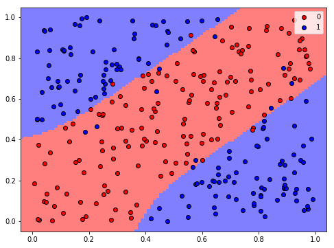

```python
from ClassificationPlotter import plot_regions

plot_regions(model, X, y, cmap='bwr_r', fig_size=(8,6), keras=True)
```

The gif below shows how the classification regions changed during the process of training.

[figure not shown]

## Making Predictions

We can used the `predict` and `predict_classes` methods of our model to generate predictions for new observations.

```python
Xnew = np.array([[0.2, 0.4], [0.2, 0.5], [0.2,0.6]])

np.set_printoptions(precision=6, suppress=True)

print('Estimated probabilities of being blue:\n', model.predict(Xnew))
print()
print('Predicted classes:\n', model.predict_classes(Xnew))
```

```
Estimated probabilities of being blue:
 [[0.028326]
 [0.204441]
 [0.835694]]

Predicted classes:
 [[0]
 [0]
 [1]]
```

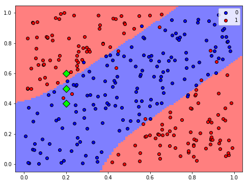

```python
plot_regions(model, X, y, cmap='bwr', fig_size=(8,6), keras=True, display=False)
plt.scatter(Xnew[:,0], Xnew[:,1], marker="D", c='lime', edgecolor='k', s=100, zorder=3)
plt.show()
```